# Network inference and analysis of CLL data

Frédéric Bertrand and Myriam Maumy-Bertrand

Université de Strasbourg et CNRS,IRMA, labex IRMIA  
frederic.bertrand@utt.fr

2024-05-04

# Data preparation

Retrieve the full CLL dataset.

```r
require(Patterns)
CLLfile <- "https://github.com/fbertran/Patterns/raw/master/add_data/CLL.RData"
repmis::source_data(CLLfile)
```

```
#> SHA-1 hash of the downloaded data file is:
#> 8dca428b86d460cd2018745029f03bc12aa8be65
#> [1] "CLL"
```

```r
CLL[1:10,1:5]
```

```
#>     probeset             nom
#> 1  1007_s_at DDR1 or MIR4640
#> 2    1053_at            RFC2
#> 3     117_at           HSPA6
#> 4     121_at            PAX8
#> 5  1255_g_at          GUCA1A
#> 6    1294_at UBA7 or MIR5193
#> 7    1316_at            THRA
#> 8    1320_at          PTPN21
#> 9  1405_i_at            CCL5
#> 10   1431_at          CYP2E1
#>    Healthy.B.cell..subject.N1_unstimulated.cells_at.60min
#> 1                                                  560.69
#> 2                                                  220.58
#> 3                                                  269.54
```

[output cut: 29 more lines]

Split the `CLL` dataset into healthy and aggressive stimulated and unstimulated dataset.

```r
hea_US<-CLL[,which((1:48)%%8<5&(1:48)%%8>0)+2]
hea_S<-CLL[,which(!((1:48)%%8<5&(1:48)%%8>0))+2]

agg_US<-CLL[,which((1:40)%%8<5&(1:40)%%8>0)+98]
agg_S<-CLL[,which(!((1:40)%%8<5&(1:40)%%8>0))+98]

m_hea_US<-as.omics_array(hea_US,c(60,90,210,390),6,name=CLL[,1],gene_ID=CLL[,2])
m_hea_S<- as.omics_array(hea_S,c(60,90,210,390),6,name=CLL[,1],gene_ID=CLL[,2])

m_agg_US<-as.omics_array((agg_US),c(60,90,210,390),5,name=CLL[,1],gene_ID=CLL[,2])
m_agg_S<- as.omics_array((agg_S),c(60,90,210,390),5,name=CLL[,1],gene_ID=CLL[,2])
```

```r
matplot(t(log(agg_S[which(CLL[,2] %in% "EGR1"),])),type="l",lty=1)
```

[output not shown]

# Selection genes according to their profiles.

```r
selection1<-geneSelection(list(m_agg_US,m_agg_S),list("condition&time",c(1,2),c(1,1)),-1,alpha=0.1)
```

```
#> [1] "The selection is not empty"
#> [1] "This function returns the stimulated expression"
```

```r
selection2<-geneSelection(list(m_agg_US,m_agg_S),list("condition&time",c(1,2),c(1,1)+1),-1,alpha=0.1)
```

```
#> [1] "The selection is not empty"
#> [1] "This function returns the stimulated expression"
```

```r
selection3<-geneSelection(list(m_agg_US,m_agg_S),list("condition&time",c(1,2),c(1,1)+2),50,alpha=0.005)
```

```
#> [1] "The selection is not empty"
#> [1] "This function returns the stimulated expression"
```

```r
selection4<-geneSelection(list(m_agg_US,m_agg_S),list("condition&time",c(1,2),c(1,1)+3),50,alpha=0.005)
```

```
#> [1] "The selection is not empty"
#> [1] "This function returns the stimulated expression"
```

Merge the four selections into a single one.

```r
selection<-Patterns::unionOmics(list(selection1,selection2,selection3,selection4))
summary(selection)
```

```
#>  CLL.B.cell..patient.M2_stimulated.cells_at.60min_.agg.
#>  Min.   : 6.776
#>  1st Qu.: 7.789
#>  Median : 8.177
#>  Mean   : 8.552
#>  3rd Qu.: 8.932
#>  Max.   :12.620
#>  CLL.B.cell..patient.M2_stimulated.cells_at.90min_.agg.
#>  Min.   : 6.429
#>  1st Qu.: 7.741
#>  Median : 8.340
#>  Mean   : 8.832
#>  3rd Qu.: 9.461
#>  Max.   :13.371
#>  CLL.B.cell..patient.M2_stimulated.cells_at.210min_.agg.
#>  Min.   : 6.408
#>  1st Qu.: 8.005
#>  Median : 8.932
#>  Mean   : 9.288
#>  3rd Qu.:10.355
#>  Max.   :13.958
#>  CLL.B.cell..patient.M2_stimulated.cells_at.390min_.agg.
#>  Min.   : 6.613
#>  1st Qu.: 8.033
#>  Median : 8.986
#>  Mean   : 9.131
#>  3rd Qu.: 9.990
#>  Max.   :14.166
#>  CLL.B.cell..patient.UM1_stimulated.cells_at.60min_.agg.
#>  Min.   : 6.855
#>  1st Qu.: 7.649
#>  Median : 8.151
#>  Mean   : 8.469
#>  3rd Qu.: 9.083
#>  Max.   :12.256
#>  CLL.B.cell..patient.UM1_stimulated.cells_at.90min_.agg.
#>  Min.   : 6.860
#>  1st Qu.: 7.748
#>  Median : 8.224
#>  Mean   : 8.585
```

[output cut: 85 more lines]

```
#>  Max.   :13.173
#>  CLL.B.cell..patient.UM4_stimulated.cells_at.210min_.agg.
#>  Min.   : 6.592
#>  1st Qu.: 8.190
#>  Median : 9.185
#>  Mean   : 9.361
#>  3rd Qu.:10.454
#>  Max.   :13.772
#>  CLL.B.cell..patient.UM4_stimulated.cells_at.390min_.agg.
#>  Min.   : 6.758
#>  1st Qu.: 7.955
#>  Median : 9.150
#>  Mean   : 9.150
#>  3rd Qu.:10.053
#>  Max.   :13.818
```

[figure not shown]

Number of genes in the merged selection.

```r
length(selection@gene_ID)
```

```
#> [1] 169
```

Translate the probesets’ names for the selection.

```r
require(biomaRt)

affyids=c("202763_at","209310_s_at","207500_at")
ensembl = useMart("ensembl",dataset="hsapiens_gene_ensembl")
infos<-getBM(attributes=c("affy_hg_u133_plus_2","ensembl_gene_id","hgnc_symbol","chromosome_name","start_position","end_position","band"), filters = "affy_hg_u133_plus_2", values = CLL[CLL[,1] %in% selection@name,1] , mart = ensembl,uniqueRows=TRUE, checkFilters = TRUE)
```

```r
selection@gene_ID <- lapply(selection@name,function(x) {unique(infos[infos$affy_hg_u133_plus_2==x,"hgnc_symbol"])})
```

# Network inference

Add groupping information according to the pre-merge selection membership to perform network inference.

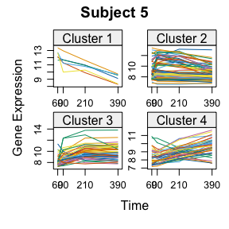

```r
selection@group <- rep(NA, length(selection@name))
names(selection@group) <- selection@name
selection@group[selection@name %in% selection4@name] <- 4
selection@group[selection@name %in% selection3@name] <- 3
selection@group[selection@name %in% selection2@name] <- 2
selection@group[selection@name %in% selection1@name] <- 1
plot(selection)
```

Check the length of the `group` slot of the `selection` object.

```r
length(selection@group)
```

```
#> [1] 169
```

Performs a lasso based inference of the network. Then prints the `network` pbject.

```r
network<-inference(selection,fitfun="LASSO2",Finit=CascadeFinit(4,4),Fshape=CascadeFshape(4,4))
```

```
#> We are at step :  1
#> Computing Group (out of 4) :
#>  1
#>  2...............................................................................
#>  3.............................................
#>  4.......................................
#> The convergence of the network is (L1 norm) : 0.00571
#> We are at step :  2
#> Computing Group (out of 4) :
#>  1
#>  2...............................................................................
#>  3.............................................
#>  4.......................................
#> The convergence of the network is (L1 norm) : 0.00122
#> We are at step :  3
#> Computing Group (out of 4) :
#>  1
#>  2...............................................................................
#>  3.............................................
#>  4.......................................
#> The convergence of the network is (L1 norm) : 0.00069
```

```r
str(network)
```

```
#> Formal class 'omics_network' [package "Patterns"] with 6 slots
#>   ..@ omics_network: num [1:169, 1:169] 0 0 0 0 0 0 0 0 0 0 ...
#>   ..@ name         : chr [1:169] "201694_s_at" "227404_s_at" "237009_at" "201693_s_at" ...
#>   ..@ F            : num [1:4, 1:4, 1:16] 0 0 0 0 0 0 0 0 0 0 ...
#>   ..@ convF        : num [1:16, 1:4] 0.141 0.141 0.141 0.141 0.141 ...
#>   .. ..- attr(*, "dimnames")=List of 2
#>   .. .. ..$ : NULL
#>   .. .. ..$ : chr [1:4] "convF" "cc" "cc" "cc"
#>   ..@ convO        : num [1:4] 8.08e+01 5.71e-03 1.22e-03 6.92e-04
#>   ..@ time_pt      : num [1:4] 60 90 210 390
```

Plot the inferred F matrix.

[figure not shown]

```r
plotF(network@F, choice='F')
```

Save results.

```r
save(list=c("selection"),file="selection.RData")
save(list=c("infos"),file="infos.RData")
```

# Focus on transcription factors.

Retrieve human transcription factors from HumanTFDB, extracted from AnimalTFDB 3.0: a comprehensive resource for annotation and prediction of animal transcription factors. Hui Hu, Ya-Ru Miao, Long-Hao Jia, Qing-Yang Yu, Qiong Zhang and An-Yuan Guo. *Nucl. Acids Res*. (2018).

```r
doc <- read.delim("http://bioinfo.life.hust.edu.cn/static/AnimalTFDB3/download/Homo_sapiens_TF",encoding = "UTF-8", header=TRUE)
TF<-as.character(doc[,"Symbol"])
TF<-TF[order(TF)]
```

The `TF` object holds the list of human transcription factors geneID. We retrieve those that are in the `selection` object.

```r
infos_selection <- infos[infos$affy_hg_u133_plus_2 %in% selection@name,]
tfs<-which(infos_selection[,"hgnc_symbol"] %in% TF)
```

Some plots of the `TF` found in the selection.

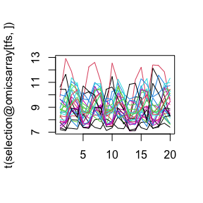

```r
matplot(t(selection@omicsarray[tfs,]),type="l",lty=1)
```

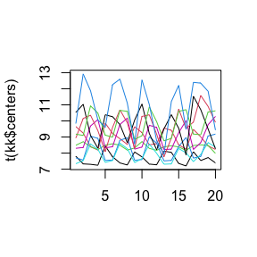

```r
kk<-kmeans((selection@omicsarray[tfs,]),10)
matplot(t(kk$centers),type="l",lty=1)
```